# Смешанные модели для бинарных зависимых величин

## Вы узнаете

- Об обобщенных смешанных линейных моделях (GLMM) и о функциях R, которые могут их рассчитать

### Вы сможете

- Построить обобщенную смешанную модель для бинарных данных.
- Применить для построения модели функции из нескольких пакетов, реализованных в R.

## Вспомним основные идеи работы с бинарными переменными

## Вопросы

- Какое распределение используют при работе с бинарными данными?
- Сколько параметров в функции плотности вероятности этого распределения?
- В каком соотношении находятся матожидание и дисперсия этого распределения?

## Биномиальное распределение

\(f(y; N, \pi) = \frac{N!}{y! \times (N-y)!} \times \pi^y \times (1 - \pi)^{N-y}\)

### Два параметра (\(N\), \(\pi\))

Среднее: &emsp;&emsp; \(E(Y) = N \times \pi\)  
Дисперсия: \(var(Y) = N \times \pi \times (1-\pi)\)  
Параметр \(N\) определяет количество объектов в испытании  
Парметр \(\pi\) - вероятность события (\(y = 1\))

### Пределы варьирования

[figure not shown]

## Вопросы

- Что такое шансы?
- Что такое логиты?
- Какую связывающую функцию обычно используются при работе с бинарными перменными отклика?

## Шансы и логиты

Дискретный отклик: 1 или 0  
Вероятност события: \(\pi = \frac{N_i}{N_{total}}\)  
Шансы (odds): \(odds=\frac{\pi}{1-\pi}\)  
*Логиты* (logit): \(ln(odds)=\ln(\frac{\pi}{1-\pi})\)

## Связывающая функция для бинарных перменных отклика

Каноническая связывающая функция - *логит-функция*: \(\eta(\pi)=\ln(\frac{\pi}{1-\pi})\)

`family = binomial(link = "logit")`

Помимо логит-функции можно применить еще несколько:

*Complementary Log-Log* связывающая функция : \(\eta(\pi)=\ln(-\ln(1-\pi))\)  
`family = binomial(link = "cloglog")`

*Пробит* - связывающая фунция: \(\eta(\pi)=\Phi^{-1}(\pi)\)  
`family = binomial(link = "probit")`

## Что где находится на этом графике?

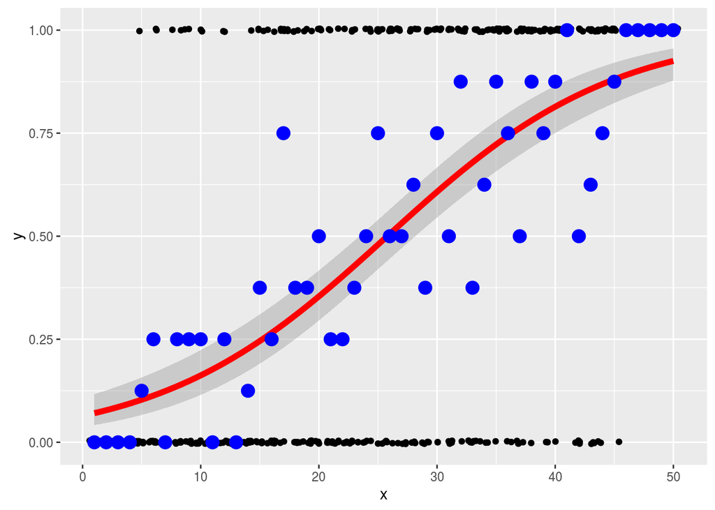

## Построение модели для бинарной переменной отклика

## Морские желуди: Кого съедят бореотрофоны?

Данные взяты из работы  
Yakovis Y., Artemieva A. "Bored to Death: Community-Wide Effect of Predation on a Foundation Species in a Low-Disturbance Arctic Subtidal System" PLOS, 2015. DOI: 10.1371/journal.pone.0132973

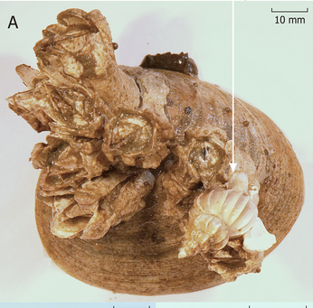

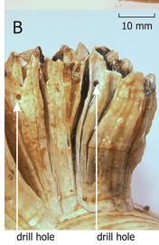

## Вопрос: от каких факторов зависит будет ли атакован балянус хищником?

Мы будем оценивать связь вероятности гибели балянуса от нападения *Boreotrophon clathratus*.

### Дизайн сбора материала

[figure not shown]

## Читаем данные

```r
bal <- read.table("data/Yakovis2.csv", header = TRUE, sep = ";")
```

```r
# Some housekeeping
bal$Site <- factor(bal$Site)
bal$Sample <- factor(bal$Sample)
bal$Substrate_ID <- factor(bal$Substrate_ID)
```

## Переменные

`Site` -точка сбора материала  
`Sample` - квдарат 1х1 м, на котором производился сбор друз  
`BorN` - количество *Boreotrophon clathratus* на квадрате  
`Substrate_ID` - Номер друзы  
`ALength` - Диаметр апертуры  
`Age` - Возраст балянуса  
`Position` - Расположение балянуса (первичный субстрат/вторичный субстрат)  
`Status` - живой/мертвый  
`Drill` - Зависимая переменная (0 - нет следов сверления; 1 - есть следы сверления)

### Для ответа на поставленный вопрос целесообразно работать с мертвыми особями

## Задание

Вычислите какая доля живых и мертвых особей несет следы сверления

## Решение

```r
bal1 <- bal[bal$Status == "live_barnacle", ]
mean(bal1$Drill == 1)
```

```
## [1] 0.0128
```

```r
bal2 <- bal[bal$Status == "empty_test", ]
mean(bal2$Drill == 1)
```

```
## [1] 0.0816
```

## Задание

### Напишите код, который задаст формулу для фиксированной части модели

## Решение

```r
Fix_effect <- formula(Drill ~ BorN + ALength + Age + Position + Site)
```

## Задание

### Напишите код, который задаст формулу для случайной части модели

## Решение

```r
Rand_effect <- formula(~1 | Sample/Substrate_ID)
```

## Согласно дизайну сбора материала, необходимо построить обобщенную смешанную линейную модель (GLMM)

Функция максимального правдоподобия для GLMM

\[Lik(\beta, D) = \Pi_i\int f(Y_i|b_i)\times f(b_i)db_i\]

Вычисление максимума функции правдоподобия для GLMM может производиться только в численном виде (аналитическое решение невозможно). Поэтому все алгоритмы очень затратны по времени.

## Инструменты `R`, позволяющие подобрать GLMM

[output not shown]

**Важно!**Во всех случаях надо с осторожостью принимать решения при уровнях значимости близкх к 5%!  
Альтернативный подход к построению сложных моделей - использование методов **Байесовской статистики**

## Подбираем модель с помощью функции `glmmPQL`

```r
library(MASS)

M1_PQL <- glmmPQL(Fix_effect, random = ~1 | Sample/Substrate_ID, data = bal2,
    family = "binomial")
```

## Результаты

```r
summary(M1_PQL)
```

```
## Linear mixed-effects model fit by maximum likelihood
##  Data: bal2
##   AIC BIC logLik
##    NA  NA     NA
##
## Random effects:
##  Formula: ~1 | Sample
##         (Intercept)
## StdDev:       0.358
##
##  Formula: ~1 | Substrate_ID %in% Sample
##         (Intercept) Residual
## StdDev:        1.62    0.704
##
## Variance function:
##  Structure: fixed weights
##  Formula: ~invwt
## Fixed effects: Drill ~ BorN + ALength + Age + Position + Site
##                   Value Std.Error   DF t-value p-value
## (Intercept)       -4.12     0.445 1908   -9.25  0.0000
## BorN               0.07     0.053    6    1.35  0.2243
## ALength            0.15     0.046 1908    3.24  0.0012
## Age               -0.10     0.077 1908   -1.29  0.1969
## Positionsecondary  1.26     0.172 1908    7.34  0.0000
## Site2             -0.30     0.612    6   -0.49  0.6437
##  Correlation:
##                   (Intr) BorN   ALngth Age    Pstnsc
## BorN              -0.776
## ALength           -0.232 -0.035
## Age                0.079  0.043 -0.907
## Positionsecondary -0.314  0.047  0.025  0.169
## Site2             -0.480  0.390 -0.021  0.042  0.069
##
## Standardized Within-Group Residuals:
##    Min     Q1    Med     Q3    Max
## -4.244 -0.366 -0.205 -0.116 13.809
##
## Number of Observations: 2120
## Number of Groups:
##                   Sample Substrate_ID %in% Sample
##                        9                      209
```

## Подбираем модель с помощью функции `glmmML()`

```r
library(glmmML)
M1_ML <- glmmML(Fix_effect, cluster = Substrate_ID, data = bal2)
M2_ML <- glmmML(Fix_effect, cluster = Sample, data = bal2)
# Коэффициенты
C_glmmML_1 <- round(as.numeric(coefficients(M1_ML)), 3)
C_glmmML_2 <- round(as.numeric(coefficients(M2_ML)), 3)
```

## Результаты первой модели

```r
glmmML::summary.glmmML(M1_ML)
```

```
##
## Call:  glmmML(formula = Fix_effect, data = bal2, cluster = Substrate_ID)
##
##
##                      coef se(coef)       z    Pr(>|z|)
## (Intercept)       -4.3674   0.4100 -10.653 0.000000000
## BorN               0.0869   0.0405   2.149 0.032000000
## ALength            0.1316   0.0609   2.162 0.031000000
## Age               -0.0677   0.1036  -0.653 0.510000000
## Positionsecondary  1.2967   0.2289   5.664 0.000000015
## Site2             -0.2901   0.5432  -0.534 0.590000000
##
## Scale parameter in mixing distribution:  1.42 gaussian
## Std. Error:                              0.164
##
##         LR p-value for H_0: sigma = 0:  4.77e-23
##
## Residual deviance: 1020 on 2113 degrees of freedom   AIC: 1030
```

## Результаты второй модели

```r
glmmML::summary.glmmML(M2_ML)
```

```
##
## Call:  glmmML(formula = Fix_effect, data = bal2, cluster = Sample)
##
##
##                      coef se(coef)      z Pr(>|z|)
## (Intercept)       -4.1523   0.4256 -9.757  0.0e+00
## BorN               0.1173   0.0491  2.388  1.7e-02
## ALength            0.0652   0.0515  1.266  2.1e-01
## Age                0.0360   0.0859  0.419  6.8e-01
## Positionsecondary  1.2242   0.1838  6.661  2.7e-11
## Site2              0.2051   0.5305  0.387  7.0e-01
##
## Scale parameter in mixing distribution:  0.458 gaussian
## Std. Error:                              0.137
##
##         LR p-value for H_0: sigma = 0:  0.00000327
##
## Residual deviance: 1090 on 2113 degrees of freedom   AIC: 1110
```

## Подбираем модель с помощью функции `glmer()`

```r
library(lme4)
M1_glmer <- glmer(Drill ~ BorN + ALength + Age + Position + Site + (1 |
    Sample/Substrate_ID), data = bal2, family = "binomial")
C_glmer <- round(lme4::fixef(M1_glmer), 3)
```

## Результаты

```r
summary(M1_glmer)
```

```
## Generalized linear mixed model fit by maximum likelihood (Laplace
##   Approximation) [glmerMod]
##  Family: binomial  ( logit )
## Formula:
## Drill ~ BorN + ALength + Age + Position + Site + (1 | Sample/Substrate_ID)
##    Data: bal2
##
##      AIC      BIC   logLik deviance df.resid
##     1033     1078     -508     1017     2112
##
## Scaled residuals:
##    Min     1Q Median     3Q    Max
## -2.399 -0.262 -0.163 -0.101  9.177
##
## Random effects:
##  Groups              Name        Variance Std.Dev.
##  Substrate_ID:Sample (Intercept) 1.8577   1.363
##  Sample              (Intercept) 0.0634   0.252
## Number of obs: 2120, groups:  Substrate_ID:Sample, 209; Sample, 9
##
## Fixed effects:
##                   Estimate Std. Error z value    Pr(>|z|)
## (Intercept)        -4.4040     0.4510   -9.76     < 2e-16 ***
## BorN                0.0941     0.0479    1.96       0.050 *
## ALength             0.1270     0.0614    2.07       0.039 *
## Age                -0.0605     0.1042   -0.58       0.561
## Positionsecondary   1.3064     0.2290    5.71 0.000000012 ***
## Site2              -0.2307     0.5862   -0.39       0.694
## ---
## Signif. codes:  0 '***' 0.001 '**' 0.01 '*' 0.05 '.' 0.1 ' ' 1
##
## Correlation of Fixed Effects:
##             (Intr) BorN   ALngth Age    Pstnsc
## BorN        -0.698
## ALength     -0.295 -0.077
## Age          0.103  0.086 -0.912
## Postnscndry -0.433  0.082  0.032  0.148
## Site2       -0.417  0.396 -0.050  0.074  0.091
```

## Сравним коэффициенты, подобранные разными функциями

```
          Parameter glmmPQL glmmML_1  glmmML_2  glmer
1       (Intercept)  -4.119   -4.367   -4.152  -4.404
2              BorN   0.072    0.087*   0.117*  0.094*
3           ALength   0.148*   0.132*   0.065   0.127*
4               Age  -0.100   -0.068    0.036  -0.061
5 Positionsecondary   1.261*   1.297*   1.224*  1.306*
6             Site2  -0.298   -0.290    0.205  -0.231
```

### Выбор на совести исследователя!

## Выбор оптимальной модели

```r
drop1(M1_glmer)
```

```
## Single term deletions
##
## Model:
## Drill ~ BorN + ALength + Age + Position + Site + (1 | Sample/Substrate_ID)
##          Df  AIC
## <none>      1033
## BorN      1 1035
## ALength   1 1035
## Age       1 1031
## Position  1 1064
## Site      1 1031
```

## Выбор оптимальной модели

```r
M2_glmer <- update(M1_glmer, . ~ . - Site)
anova(M1_glmer, M2_glmer)
```

```
## Data: bal2
## Models:
## M2_glmer: Drill ~ BorN + ALength + Age + Position + (1 | Sample/Substrate_ID)
## M1_glmer: Drill ~ BorN + ALength + Age + Position + Site + (1 | Sample/Substrate_ID)
##          Df  AIC  BIC logLik deviance Chisq Chi Df Pr(>Chisq)
## M2_glmer  7 1031 1071   -509     1017
## M1_glmer  8 1033 1078   -508     1017  0.15      1       0.69
```

## Выбор оптимальной модели

```r
drop1(M2_glmer)
```

```
## Single term deletions
##
## Model:
## Drill ~ BorN + ALength + Age + Position + (1 | Sample/Substrate_ID)
##          Df  AIC
## <none>      1031
## BorN      1 1034
## ALength   1 1033
## Age       1 1029
## Position  1 1063
```

## Выбор оптимальной модели

```r
M3_glmer <- update(M2_glmer, . ~ . - Age)
anova(M2_glmer, M3_glmer)
```

```
## Data: bal2
## Models:
## M3_glmer: Drill ~ BorN + ALength + Position + (1 | Sample/Substrate_ID)
## M2_glmer: Drill ~ BorN + ALength + Age + Position + (1 | Sample/Substrate_ID)
##          Df  AIC  BIC logLik deviance Chisq Chi Df Pr(>Chisq)
## M3_glmer  6 1029 1063   -509     1017
## M2_glmer  7 1031 1071   -509     1017  0.31      1       0.58
```

## Выбор оптимальной модели

```r
drop1(M3_glmer)
```

```
## Single term deletions
##
## Model:
## Drill ~ BorN + ALength + Position + (1 | Sample/Substrate_ID)
##          Df  AIC
## <none>      1029
## BorN      1 1032
## ALength   1 1042
## Position  1 1064
```

## Результаты

```r
summary(M3_glmer)
```

```
## Generalized linear mixed model fit by maximum likelihood (Laplace
##   Approximation) [glmerMod]
##  Family: binomial  ( logit )
## Formula:
## Drill ~ BorN + ALength + Position + (1 | Sample/Substrate_ID)
##    Data: bal2
##
##      AIC      BIC   logLik deviance df.resid
##     1029     1063     -509     1017     2114
##
## Scaled residuals:
##    Min     1Q Median     3Q    Max
## -2.371 -0.262 -0.163 -0.103  9.193
##
## Random effects:
##  Groups              Name        Variance Std.Dev.
##  Substrate_ID:Sample (Intercept) 1.8092   1.345
##  Sample              (Intercept) 0.0773   0.278
## Number of obs: 2120, groups:  Substrate_ID:Sample, 209; Sample, 9
##
## Fixed effects:
##                   Estimate Std. Error z value     Pr(>|z|)
## (Intercept)        -4.4498     0.4108  -10.83      < 2e-16 ***
## BorN                0.1035     0.0450    2.30      0.02154 *
## ALength             0.0948     0.0252    3.76      0.00017 ***
## Positionsecondary   1.3335     0.2256    5.91 0.0000000034 ***
## ---
## Signif. codes:  0 '***' 0.001 '**' 0.01 '*' 0.05 '.' 0.1 ' ' 1
##
## Correlation of Fixed Effects:
##             (Intr) BorN   ALngth
## BorN        -0.663
## ALength     -0.517 -0.015
## Postnscndry -0.462  0.040  0.411
```

## Проверка валидности модели

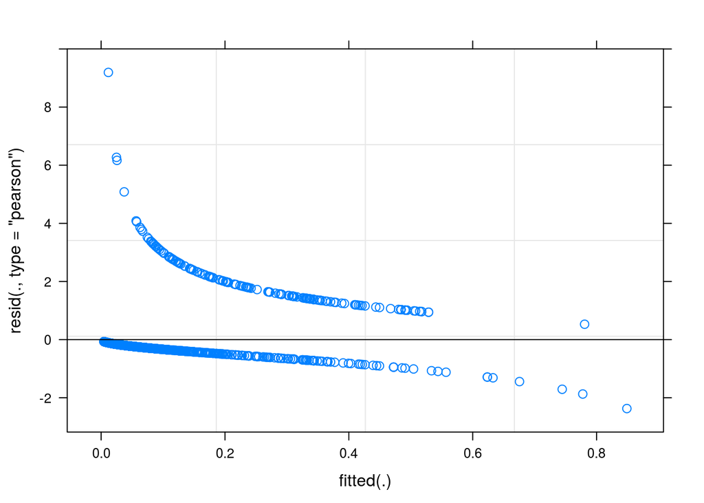

```r
plot(M3_glmer)
```

## Проверка валидности модели

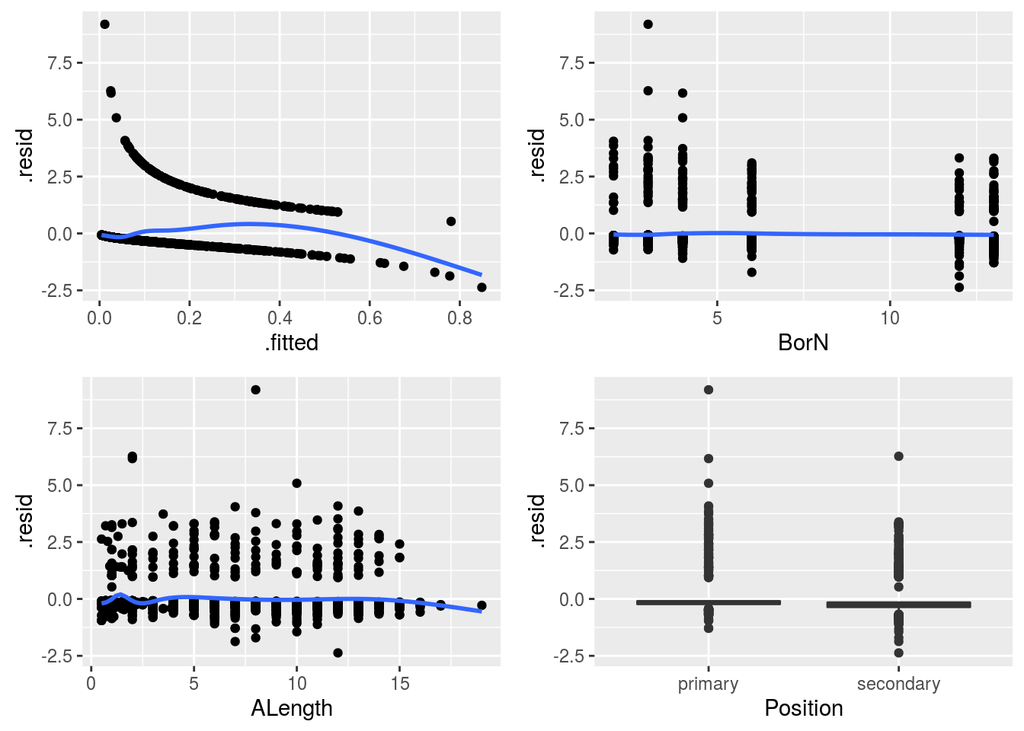

## Визуализация предсказаний модели

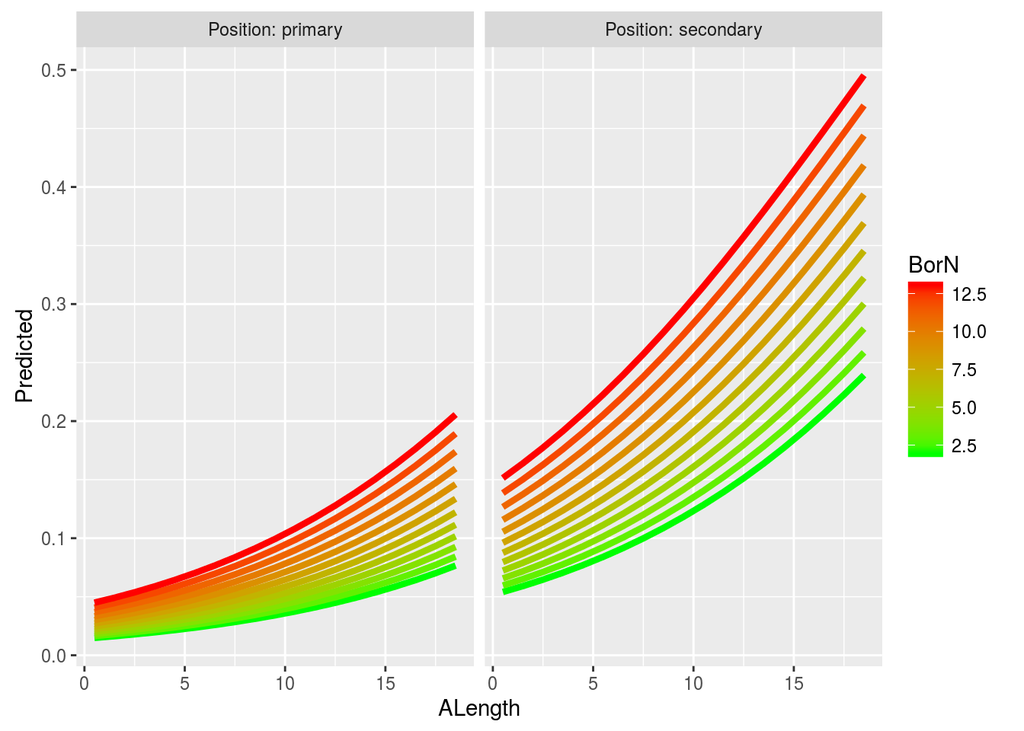

## Summary

- Построение обобщенных смешанных моделей (GLMM) для бинарных перменных отклика аналогично построению моделей для GLM и LMM.
- Идеального алгоритма для построения GLMM пока нет.
- Существующие ныне алгоритмы пригодны только для простых моделей.

## Что почитать

- Zuur, A.F. et al. 2009. Mixed effects models and extensions in ecology with R. - Statistics for biology and health. Springer, New York, NY.